# A3 - Incarceration Data Analysis

Kenny Pham

11/19/2021

## Domain: Gravity of Black Incarceration in Reference of Other Races

Although analyzing every hidden corner of inequality in this dataset would be ideal, it’s so much data that it can support thousands of research reports. I decided to focus in on identifying the gravity black incarceration in reference of other races included in the data. With 2020’s protests bringing worldwide attention to black inequality in all aspects of our society, I hope to contribute to this discussion through general and comparative analysis. Additionally, black incarceration has been an intense point of discussion throughout the U.S.’s history.

## Summary Variables

**Variables Chosen to Analyze:**

**Variable Set 1:** Between all states, how many, when, and where the most incarcerated black populations reside:

- Black: 13143.92 (hundreds), 1993, CA, Los Angeles County

I chose to analyze this variable to give me a general idea of the scale I would be working with going forward. Starting off with the black incarcerated population since it’s my domain of interest.

**Variable Set 2:** Between all states, how many, when, and where the most incarcerated white populations reside:

- White: 7036.59 (hundreds), 1993, CA, Los Angeles County

Again, I chose to analyze this variable to give me an idea of the population scale. Second is the white incarcerated population because based off of my own experiences, there are an incredible amount of incarceration discussions revolving around black vs. white populations.

**Variable Set 3:** Both the ratios for the highest single incarcerated black and white populations to each respective year’s total population (both ended up being 1993 in CA, Los Angeles County, which allows for an equivalent ratio comparison). Additionally, ratio of incarcerated black to white populations:

- Black/Total - 0.5600977
- White/Total - 0.299848
- Black/White: 1.867939

I chose these variables to put into perspective the ratio difference between black and white incarcerated populations. This gave already started me off in identifying the ‘gravity’ of black incarceration by comparing multiplicity.

I chose these variables to further my understanding of the gravity of black incarceration in comparison to other races. Additionally, this allowed me to identify location trends (CA, Los Angeles County is significant).

**Variable Set 5:** In the most recent year, the highest single population for incarcerated black, white, AAPI, latinx, and ‘other race’ individuals across all states

- Black: 5024 (hundreds)
- White: 4577 (hundreds)
- AAPI: 286.4 (hundreds)
- Latinx: 8728 (hundreds)
- Native: 379 (hundreds)
- ‘Other Race’: 608 (hundreds)

I chose these variables to apply my thoughts so far to modern day (2018, the most recent year data) and check if my initial analysis was applicable over time. Generally, it did and it helped me decide on relevant graph analyses.

## Summary of Summary Statistics

**Variable Set 1** showed an incredibly high maximum population for a single black incarcerated population in CA in 1993. This ultimately pales in comparison to the white incarcerated population shown in **Variable Set 2** for the same location and time, with it being almost half of the black incarcerated population. **Variable Set 3** further highlights this point, showing that the black incarcerated population maximum compared to the white incarcerated population maximum is specifically around 1.8x as much. Additionally, the black incarcerated population makes up around 56% of the total population for that year. **Variable Set 4** identifies the same information for all other listed races, showing there is a significant amount of incarcerations in CA, Los Angeles County. Furthermore, going against my assumptions and showing that the latinx incarcerated population has the highest maximum out of any race. **Variable Set 5** finalizes analysis of the maximum values by comparing the incarcerated population values between all races in modern day. It confirms that the black and latinx incarcerated populations are still the two highest values, with the gravity being visualized in the attached graphs.

## Graph 1 - Trends Over Time: Bar chart comparing the 10 highest incarcerated populations over time for each race (by year)

I included this bar chart to visualize the maximum incarcerated population analysis I conducted in my variable analysis. A bar chart over a line char because it still effectively measures change over time while providing additional visualization cues directly in comparison with other races. Although I had to keep it to the 10 highest values due to the limitations of the project, it still shows incredibly interesting trends. A bar chart was chosen to visually and easily identify skews in the data alongside it being a user-friendly visualization for the comparison of multiple values. These particular points can be made:

- The the maximums for all other populations other than black and latinx never reach the lowest maximum for these two populations.
- There is a peak in maximum incarcerated population around 1993 (it’s skewed towards 1993).
- Given this, the 21st century has lower maximums overall than recorded incarcerated population values in the late-20th century.
- Black and latinx incarcerated populations have the two highest sets of maximums and largely overlap at the same time period (at the skewed point around 1993).

## Graph 2 - Variable Comparison Chart: Boxplots of the 10 highest incarcerated black populations and the total incarcerated populations for each of their respective years.

Conclusively, these boxplots show us that the black incarcerated population, throughout its historic highs, have constituted a **significant** portion of the total incarcerated population for their respective years. There’s no doubt that the black incarcerated population represents significant inequality compared to other races (other than latinx which we identified in the previous graph).

## Graph 3 - Map: Density of the Total Black Incarcerated Population by County

I decided to focus on visualizing the density of the total black incarcerated population by county to identify general, prominent key areas. I chose counties instead of states because based on my previous analysis, the highest incarcerated black populations are condensed into a select number of counties, not states as a whole. The map is powerful in that it shows how heavily skewed some individual counties are despite their relative size to lower black incarcerated population counties. In the map, blue represents lower populations, while a gradient increasing to a bright red (highest population) represents higher populations. Gray areas represent no data. The map shows:

- Prominent, high black incarcerated populations reside within the southwest, southeast, and east areas of the U.S.
- The collection of data is skewed to the east of the U.S., while there is less data collected from the central to west of the U.S.
- Central U.S. consistently has blue, meaning its counties’ general black incarcerated populations are relatively lower.

## Graphs 1-3

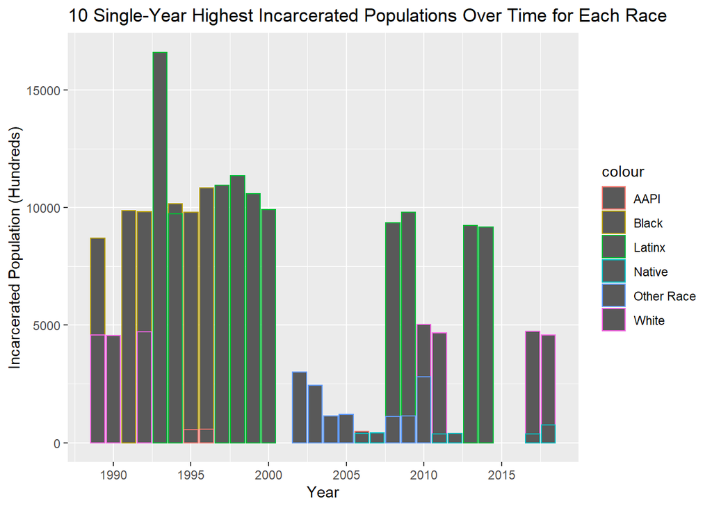

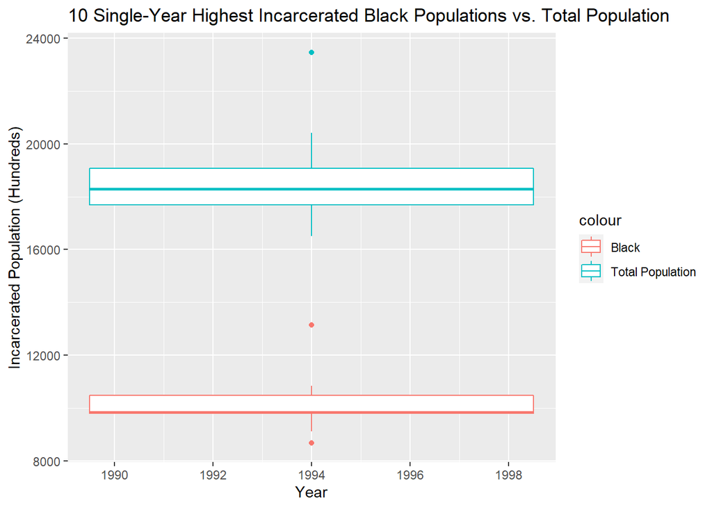

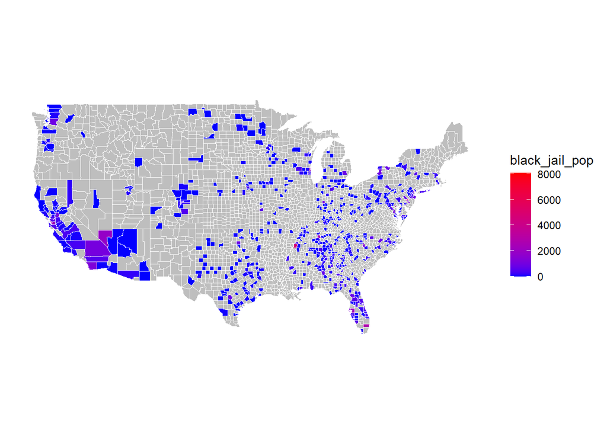